# Chap3 Exercise

## Question 1

### (a) Fit the model

Read the data:

```r
d1 <- read.table("../ARM_Data/exercise2.1.dat", header=T)
d1_40 <- d1[0:40,]
head(d1_40)
```

|  | y | x1 | x2 |
| --- | --- | --- | --- |
| 1 | 15.68 | 6.87 | 14.09 |
| 2 | 6.18 | 4.40 | 4.35 |
| 3 | 18.10 | 0.43 | 18.09 |
| 4 | 9.07 | 2.73 | 8.65 |
| 5 | 17.97 | 3.25 | 17.68 |
| 6 | 10.04 | 5.30 | 8.53 |

Fit the model:

```r
fit1a <- lm(y ~ x1 + x2, data=d1_40)
summary(fit1a)
```

```
Call:
lm(formula = y ~ x1 + x2, data = d1_40)

Residuals:
    Min      1Q  Median      3Q     Max
-0.9585 -0.5865 -0.3356  0.3973  2.8548

Coefficients:
            Estimate Std. Error t value Pr(>|t|)
(Intercept)  1.31513    0.38769   3.392  0.00166 **
x1           0.51481    0.04590  11.216 1.84e-13 ***
x2           0.80692    0.02434  33.148  < 2e-16 ***
---
Signif. codes:  0 ‘***’ 0.001 ‘**’ 0.01 ‘*’ 0.05 ‘.’ 0.1 ‘ ’ 1

Residual standard error: 0.9 on 37 degrees of freedom
Multiple R-squared:  0.9724,    Adjusted R-squared:  0.9709
F-statistic: 652.4 on 2 and 37 DF,  p-value: < 2.2e-16
```

From the summary info, the coefficients for both x1 and x2 are significantly larger than 0. The variance explained $R^2$ is very high. Residual standard deviation is 0.9, so residual variance is 0.81, $R^2$ could be calculated by $1-\sigma^2/Var(y)$, which is consistent with the summary output:

```r
1-0.81/var(d1_40$y)
```

```
[1] 0.9709356
```

### (b) Display the data and fit

Plot the data and fit:

```r
par(mfrow=c(1,2))
plot(d1_40$x1, d1_40$y, xlab='x1', ylab='y')
# add the fit curve when evaluate x2 at its mean value
curve(cbind(1,x,mean(d1_40$x2)) %*% coef(fit1a), add=T)
```

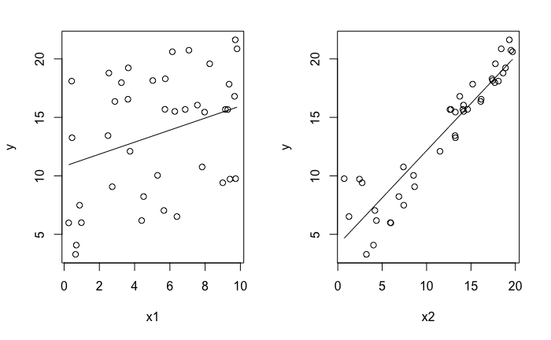

```r
# do the same for x2
plot(d1_40$x2, d1_40$y, xlab='x2', ylab='y')
curve(cbind(1,mean(d1_40$x1), x) %*% coef(fit1a), add=T)
```

### (c) Residual plot

Plot residuals again predicted value and each predictor:

```r
resid <- residuals(fit1a)
pred <- predict(fit1a)
par(mfrow=c(1,3))
plot(pred, resid, xlab='Predicted values', ylab='Residuals')
plot(d1_40$x1, resid, xlab='x1', ylab='Residuals')
```

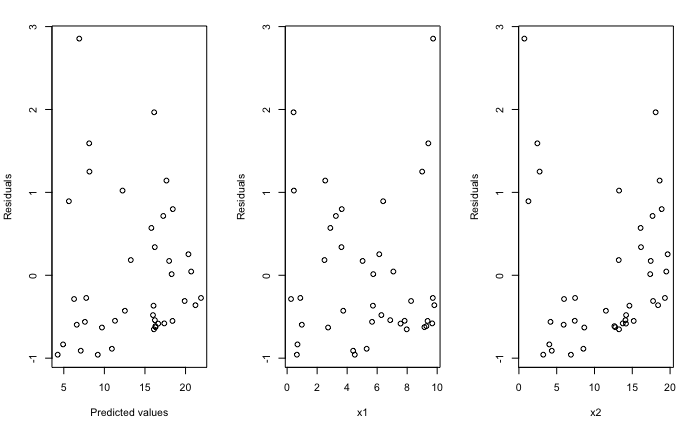

```r
plot(d1_40$x2, resid, xlab='x2', ylab='Residuals')
```

### (d) Make predictions

```r
d1_20 <- d1[41:60,]
pred_new <- predict(fit1a, d1_20)
pred_new
```

```
       41        42        43        44        45        46        47        48        49        50
14.812484 19.142865  5.916816 10.530475 19.012485 13.398863  4.829144  9.145767  5.892489 12.338639
       51        52        53        54        55        56        57        58        59        60
18.908561 16.064649  8.963122 14.972786  5.859744  7.374900  4.535267 15.133280  9.100899 16.084900
```

The confidence of prediction could be assessed by the residual standard deviation, since it’s 0.9, so I expect the predicted values to be with $y+-2*0.9$ range.

## Question 2

### (a) Regression line

Regression line is given by $log(Earning)=0.8*log(Height)+6.96+\epsilon$. Residual standard deviation is log(1.1)/2, which is 0.0477.

### (b) Variance explained

$R^2=1-\sigma^2/var(Y)$, here we know $\sigma=0.0477$, but we don’t know var(Y), so don’t know how to calculate the $R^2$.

## Question 3

### (a) Regression of independent variables

```r
var1 <- rnorm(1000, mean=0, sd=1)
var2 <- rnorm(1000, mean=0, sd=1)
fit3a <- lm(var2 ~ var1)
summary(fit3a)
```

```
Call:
lm(formula = var2 ~ var1)

Residuals:
     Min       1Q   Median       3Q      Max
-2.91878 -0.68713 -0.01295  0.70432  2.86086

Coefficients:
            Estimate Std. Error t value Pr(>|t|)
(Intercept) -0.01046    0.03150  -0.332    0.740
var1        -0.02179    0.03211  -0.679    0.497

Residual standard error: 0.9956 on 998 degrees of freedom
Multiple R-squared:  0.0004615, Adjusted R-squared:  -0.0005401
F-statistic: 0.4608 on 1 and 998 DF,  p-value: 0.4974
```

The results varies from simulation to simulation, but most cases it’s not significant.

### (b) How many times significant

```r
fit3b_zscore <- c()
for(i in 0:100){
  var1 <- rnorm(1000, mean=0, sd=1)
  var2 <- rnorm(1000, mean=0, sd=1)
  fit3b <- lm(var2 ~ var1)
  fit3b_summary <- summary(fit3b)
  fit3b_zscore[i] <- coef(fit3b)[2] / fit3b_summary$coefficients[2,2]
}
# how many times larger than 2?
fit3b_zscore_sig <- fit3b_zscore>2
sum(fit3b_zscore_sig)
```

```
[1] 5
```

## Question 4

#### (a) Fit a one-predictor model

Read the data:

```r
library("foreign")
iq.data <- read.dta("../ARM_Data/child.iq/child.iq.dta")
head(iq.data)
```

|  | ppvt | educ_cat | momage |
| --- | --- | --- | --- |
| 1 | 120 | 2 | 21 |
| 2 | 89 | 1 | 17 |
| 3 | 78 | 2 | 19 |
| 4 | 42 | 1 | 20 |
| 5 | 115 | 4 | 26 |
| 6 | 97 | 1 | 20 |

Fit a model:

```r
fit4a <- lm(ppvt ~ momage, data=iq.data)
summary(fit4a)
```

```
Call:
lm(formula = ppvt ~ momage, data = iq.data)

Residuals:
    Min      1Q  Median      3Q     Max
-67.109 -11.798   2.971  14.860  55.210

Coefficients:
            Estimate Std. Error t value Pr(>|t|)
(Intercept)  67.7827     8.6880   7.802 5.42e-14 ***
momage        0.8403     0.3786   2.219    0.027 *
---
Signif. codes:  0 ‘***’ 0.001 ‘**’ 0.01 ‘*’ 0.05 ‘.’ 0.1 ‘ ’ 1

Residual standard error: 20.34 on 398 degrees of freedom
Multiple R-squared:  0.01223,   Adjusted R-squared:  0.009743
F-statistic: 4.926 on 1 and 398 DF,  p-value: 0.02702
```

Plot the data points:

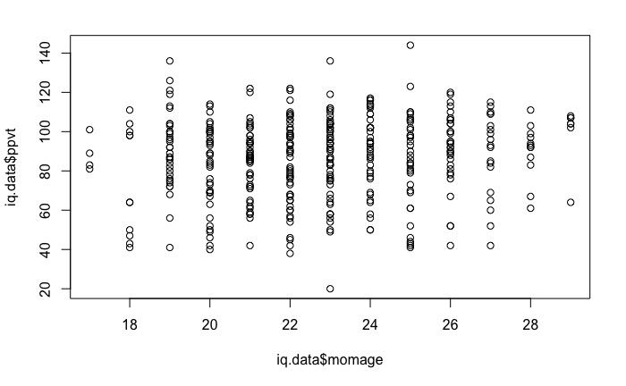

```r
plot(iq.data$momage, iq.data$ppvt)
```

Interpretation: when child’s score increase 0.84 in average when mom’s age increase by 1. Recommendation is give birth the later the better.  
Plot the residuals:

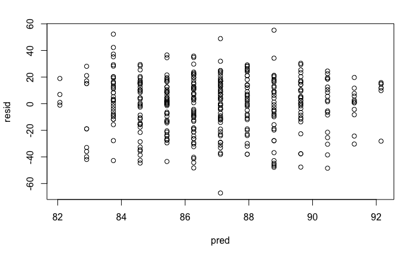

```r
resid <- residuals(fit4a)
pred <- predict(fit4a)
plot(pred, resid)
```

#### (b) Fit a two-predictor model

```r
fit4b <- lm(ppvt ~ educ_cat + momage, data=iq.data)
summary(fit4b)
```

```
Call:
lm(formula = ppvt ~ educ_cat + momage, data = iq.data)

Residuals:
    Min      1Q  Median      3Q     Max
-61.763 -13.130   2.495  14.620  55.610

Coefficients:
            Estimate Std. Error t value Pr(>|t|)
(Intercept)  69.1554     8.5706   8.069 8.51e-15 ***
educ_cat      4.7114     1.3165   3.579 0.000388 ***
momage        0.3433     0.3981   0.862 0.389003
---
Signif. codes:  0 ‘***’ 0.001 ‘**’ 0.01 ‘*’ 0.05 ‘.’ 0.1 ‘ ’ 1

Residual standard error: 20.05 on 397 degrees of freedom
Multiple R-squared:  0.04309,   Adjusted R-squared:  0.03827
F-statistic: 8.939 on 2 and 397 DF,  p-value: 0.0001594
```

After adding mom’s education, effect of mom’s age is not significant anymore, which suggests that effect we saw for the single-predictor model is because there is a positive correlation between mom’s age and mom’s education.

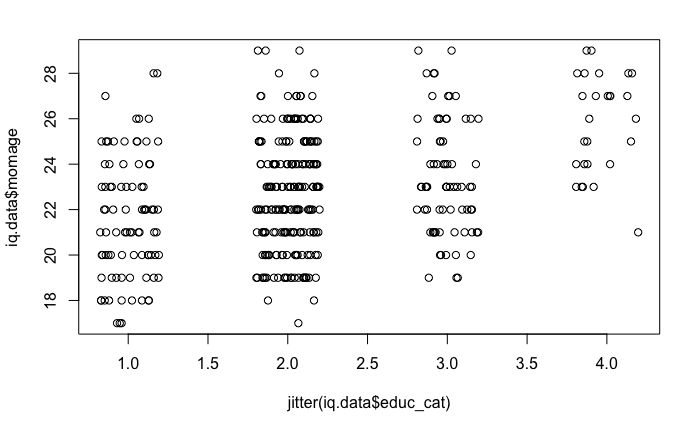

```r
plot(iq.data$momage ~ jitter(iq.data$educ_cat))
```

```r
cor.test(iq.data$educ_cat, iq.data$momage)
```

```
    Pearson's product-moment correlation

data:  iq.data$educ_cat and iq.data$momage
t = 7.4251, df = 398, p-value = 6.912e-13
alternative hypothesis: true correlation is not equal to 0
95 percent confidence interval:
 0.2596393 0.4320848
sample estimates:
     cor
0.348811
```

### (c) Indicator variable

```r
# create the high school indicator variable, assuming that greater than 1 is completed high school
iq.data$hs <- as.numeric(iq.data$educ_cat > 1)
head(iq.data)
```

|  | ppvt | educ_cat | momage | hs |
| --- | --- | --- | --- | --- |
| 1 | 120 | 2 | 21 | 1 |
| 2 | 89 | 1 | 17 | 0 |
| 3 | 78 | 2 | 19 | 1 |
| 4 | 42 | 1 | 20 | 0 |
| 5 | 115 | 4 | 26 | 1 |
| 6 | 97 | 1 | 20 | 0 |

```r
fit4c <- lm(ppvt ~ momage + hs + momage:hs, data=iq.data)
summary(fit4c)
```

```
Call:
lm(formula = ppvt ~ momage + hs + momage:hs, data = iq.data)

Residuals:
    Min      1Q  Median      3Q     Max
-56.696 -12.407   2.022  14.804  54.343

Coefficients:
            Estimate Std. Error t value Pr(>|t|)
(Intercept) 105.2202    17.6454   5.963 5.49e-09 ***
momage       -1.2402     0.8113  -1.529   0.1271
hs          -38.4088    20.2815  -1.894   0.0590 .
momage:hs     2.2097     0.9181   2.407   0.0165 *
---
Signif. codes:  0 ‘***’ 0.001 ‘**’ 0.01 ‘*’ 0.05 ‘.’ 0.1 ‘ ’ 1

Residual standard error: 19.85 on 396 degrees of freedom
Multiple R-squared:  0.06417,   Adjusted R-squared:  0.05708
F-statistic: 9.051 on 3 and 396 DF,  p-value: 8.276e-06
```

Plot the two categories separately:

```r
col <- ifelse(iq.data$hs>0, 'blue', 'red')
plot(iq.data$momage, iq.data$ppvt, col=col)
legend('topleft', legend=c('hs=1', 'hs=0'), fill=c('blue', 'red'))
```

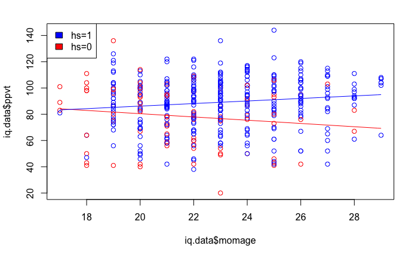

```r
curve(cbind(1,x,0,0) %*% coef(fit4c), add=T, col='red')
curve(cbind(1,x,1,x) %*% coef(fit4c), add=T, col='blue')
```

Interestingly, the trend of child’s score on mom’s age is positive for mom who completed high school, but negative for mom who didn’t, which kinda make sense.

#### (d) Make predictions

```r
iq.data.model <- iq.data[0:200,]
iq.data.pred <- iq.data[201:400,]
fit4d <- lm(ppvt ~ educ_cat + momage, data=iq.data.model)
summary(fit4d)
```

```
Call:
lm(formula = ppvt ~ educ_cat + momage, data = iq.data.model)

Residuals:
    Min      1Q  Median      3Q     Max
-46.358 -12.967   2.866  14.435  58.428

Coefficients:
            Estimate Std. Error t value Pr(>|t|)
(Intercept)  63.6295    11.8202   5.383 2.07e-07 ***
educ_cat      5.4434     1.8228   2.986  0.00318 **
momage        0.4473     0.5516   0.811  0.41836
---
Signif. codes:  0 ‘***’ 0.001 ‘**’ 0.01 ‘*’ 0.05 ‘.’ 0.1 ‘ ’ 1

Residual standard error: 19.58 on 197 degrees of freedom
Multiple R-squared:  0.06199,   Adjusted R-squared:  0.05246
F-statistic: 6.509 on 2 and 197 DF,  p-value: 0.001831
```

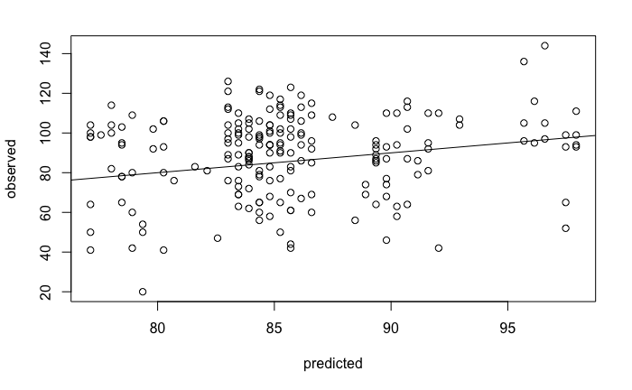

```r
pred <- predict(fit4d, iq.data.pred)
plot(pred, iq.data.pred$ppvt, xlab='predicted', ylab='observed')
abline(a=0, b=1)
```

## Question 5

### (a) Fit one-predictor model

Read the data:

```r
d5 <- read.csv('../ARM_Data/ProfEvaltnsBeautyPublic.csv')
head(d5)
```

|  | tenured | profnumber | minority | age | beautyf2upper | beautyflowerdiv | beautyfupperdiv | beautym2upper | beautymlowerdiv | beautymupperdiv | btystdave | btystdf2u | btystdfl | btystdfu | btystdm2u | btystdml | btystdmu | class1 | class2 | class3 | class4 | class5 | class6 | class7 | class8 | class9 | class10 | class11 | class12 | … |
| --- | --- | --- | --- | --- | --- | --- | --- | --- | --- | --- | --- | --- | --- | --- | --- | --- | --- | --- | --- | --- | --- | --- | --- | --- | --- | --- | --- | --- | --- | --- |
| 1 | 0 | 1 | 1 | 36 | 6 | 5 | 7 | 6 | 2 | 4 | 0.2015666 | 0.2893519 | 0.4580018 | 0.8758139 | 0.6817153 | -0.9000649 | -0.1954181 | 0 | 0 | 1 | 0 | 0 | 0 | 0 | 0 | 0 | 0 | 0 | 0 | … |
| 2 | 1 | 2 | 0 | 59 | 2 | 4 | 4 | 3 | 2 | 3 | -0.8260813 | -1.6193560 | -0.0735065 | -0.5770065 | -1.1319040 | -0.9000649 | -0.6546507 | 0 | 0 | 0 | 0 | 0 | 0 | 0 | 0 | 0 | 0 | 0 | 0 | … |
| 3 | 1 | 3 | 0 | 51 | 5 | 5 | 2 | 3 | 2 | 3 | -0.6603327 | -0.1878249 | 0.4580018 | -1.5455530 | -1.1319040 | -0.9000649 | -0.6546507 | 0 | 0 | 0 | 1 | 0 | 0 | 0 | 0 | 0 | 0 | 0 | 0 | … |
| 4 | 1 | 4 | 0 | 40 | 4 | 2 | 5 | 2 | 3 | 3 | -0.7663125 | -0.6650018 | -1.1365230 | -0.0927330 | -1.7364440 | -0.3125226 | -0.6546507 | 0 | 1 | 0 | 0 | 0 | 0 | 0 | 0 | 0 | 0 | 0 | 0 | … |
| 5 | 0 | 5 | 0 | 31 | 9 | 7 | 9 | 6 | 7 | 6 | 1.4214450 | 1.7208830 | 1.5210190 | 1.8443610 | 0.6817153 | 2.0376470 | 0.7230470 | 0 | 0 | 0 | 0 | 0 | 0 | 0 | 0 | 0 | 0 | 0 | 0 | … |
| 6 | 1 | 6 | 0 | 62 | 5 | 6 | 6 | 6 | 5 | 5 | 0.5002196 | -0.1878249 | 0.9895102 | 0.3915404 | 0.6817153 | 0.8625621 | 0.2638144 | 0 | 0 | 0 | 0 | 0 | 0 | 0 | 0 | 0 | 0 | 0 | 0 | … |

Fit the model:

```r
fit5a <- lm(courseevaluation ~ btystdave, data=d5)
summary(fit5a)
```

```
Call:
lm(formula = courseevaluation ~ btystdave, data = d5)

Residuals:
     Min       1Q   Median       3Q      Max
-1.80015 -0.36304  0.07254  0.40207  1.10373

Coefficients:
            Estimate Std. Error t value Pr(>|t|)
(Intercept)  4.01002    0.02551 157.205  < 2e-16 ***
btystdave    0.13300    0.03218   4.133 4.25e-05 ***
---
Signif. codes:  0 ‘***’ 0.001 ‘**’ 0.01 ‘*’ 0.05 ‘.’ 0.1 ‘ ’ 1

Residual standard error: 0.5455 on 461 degrees of freedom
Multiple R-squared:  0.03574,   Adjusted R-squared:  0.03364
F-statistic: 17.08 on 1 and 461 DF,  p-value: 4.247e-05
```

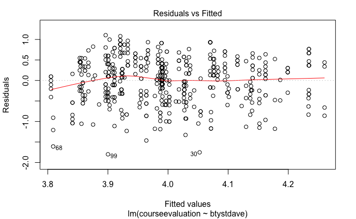

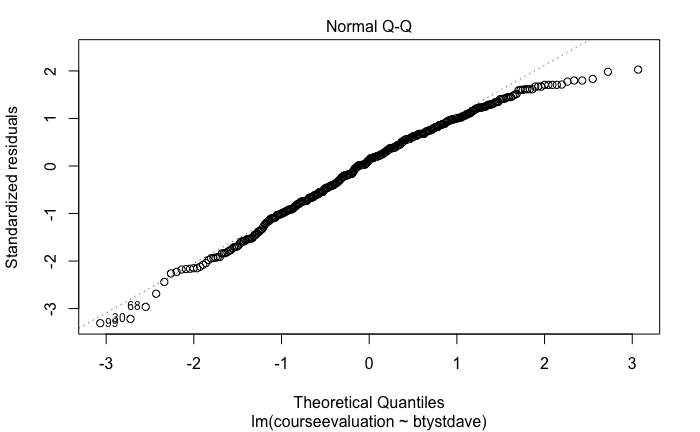

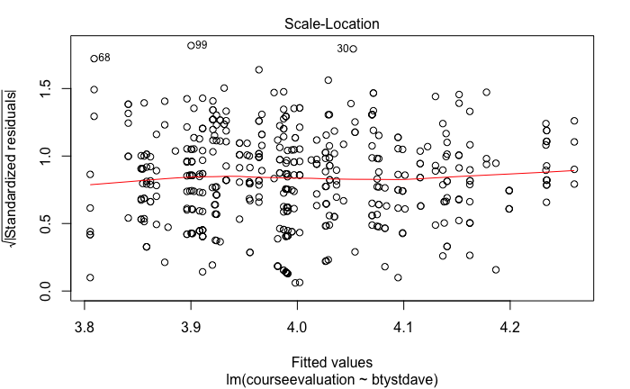

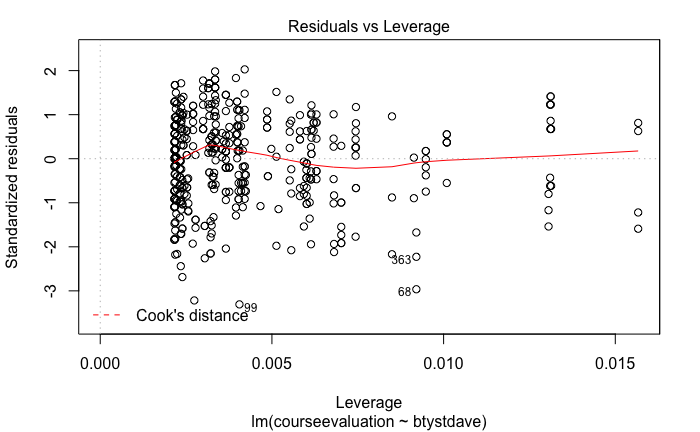

```r
plot(fit5a)
```